# Spotify Report: What on Earth do I listen to?

Author

Brad Charlton

## Preface

I found my top 50 artists from the past year (provided by https://www.statsforspotify.com), cherry-picked a bunch I think are particularly relevant, and now I’m making my own Spotify Wrapped (excluded artists were those that crept in because I listen to them to fall asleep and not in my day-to-day listening).

Why? Because I could.

### Limitations

I would love to do this report with all 50 artists and their full discographies. But alas, I cannot due to data set limitations

For example, out of the 114000 tracks in the data set (yes I counted), it has only managed to capture 7 tracks by Twenty One Pilots. The albums aren’t even correct for 3 of them!

## Initialisation

This clears the environment, loads all the required packages and reads the CSV containing information I dragged out of the larger data set.

```r
rm(list=ls())     #Clears environment

library(ggplot2)  #Makes pretty plots
library(dplyr)    #Adds dataframe functionality
library(reshape2) #See above
library(pals)     #Pretty colours

music_data <- read.csv('Data Files/artists.csv')
```

## Data Cleaning

Before compiling the CSV, I went through and made it so that each song had only one artist (many songs had multiple and that’s a bit of a pain to deal with).

There are likely duplicates of songs that need to be removed: namely live songs that don’t have a non-live version in the data set and remixes of songs. This needs to be done carefully as some regular songs also contain the string “live” in their title.

This trims the original 931 songs down to 402

```r
#Removes duplicates by track name
music_data <- distinct(music_data, track_name, .keep_all = TRUE)

#Removes Arctic Monkey's performances at the Royal Alber Hall
music_data <- music_data[!grepl("Live at the Royal Albert Hall", music_data$album_name),]

#Removes remixes
music_data <- music_data %>%
  filter(!grepl("Remix", track_name))

#Removes duplicates of The Prodigy's songs
temp <- subset(music_data, artists == "The Prodigy")
music_data <- filter(music_data, !grepl("The Prodigy", artists))
temp <- filter(temp, !grepl("- Live", track_name))
music_data <- rbind(music_data, temp)
rm(temp)
```

## Data Analysis

Initial counting yields 15 artists in the cleaned data set, covering 21 genres

```r
#Gets artists, genres, and counts for each
artist_list <- unique(music_data$artists)
genre_list <- unique(music_data$track_genre)
artist_count <- length(artist_list)
genre_count <- length(genre_list)
```

### How many tracks of each genre are there?

From the bar chart, there’s a lot of tracks in some genres and not a lot in others. Let’s see who contributes most to each genre.

[figure not shown]

```r
#Make matrix of number of tracks in each genre
track_count_by_genre <- array(NA, dim = c(genre_count, 2))
for(i in 1:genre_count){
  track_count_by_genre[i,1] <- genre_list[i]
  track_count_by_genre[i,2] <- length(which(music_data$track_genre == genre_list[i]))
}
#Make into a dataframe
track_count_by_genre <- as.data.frame(track_count_by_genre)
colnames(track_count_by_genre) <- c("Genre", "Track_Count")
#Plot
ggplot(track_count_by_genre, aes(x = Genre, y = Track_Count)) +
  geom_bar(stat = "identity") +
  labs(y = "Track Count") +
  coord_flip()
```

### What do the artists produce?

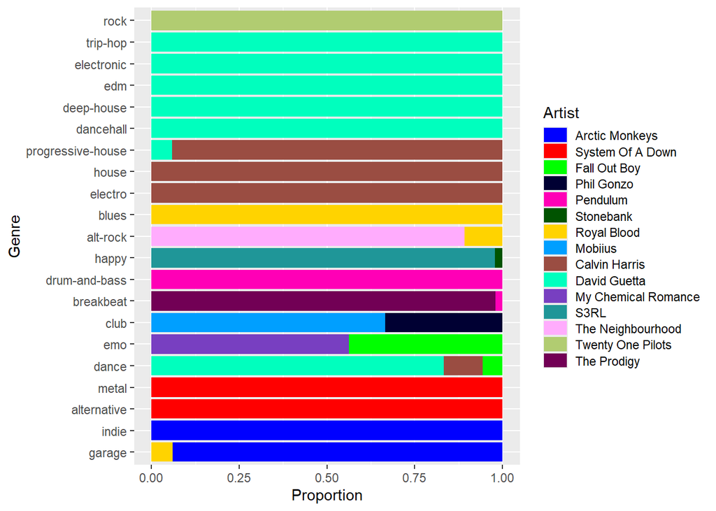

```r
#Make an array of all genres each artist makes
music_matrix <- array(0, dim = c(artist_count, genre_count), dimnames = list(artist_list, genre_list))
for(artist in artist_list){
  artist_details <- subset(music_data, artists == artist)
  artist_genres <- unique(artist_details$track_genre)
  for(genre in artist_genres){
    music_matrix[artist, genre] <- sum(artist_details$track_genre == genre)
  }
}
#Make it in long format
music_matrix_long <- melt(music_matrix)
colnames(music_matrix_long) <- c("Artist", "Genre", "Count")

#Make colours and adjust for readability
colours <- glasbey()
temp <- colours[15]
colours[15] <- colours[19]
colours[19] <- temp
rm(temp)
#Make a percent stacked barchart
ggplot(music_matrix_long, aes(x = Genre, y = Count, fill = Artist)) +
  geom_bar(position = "fill", stat="identity") +
  theme(legend.key.height = unit(0.4, "cm")) +
  scale_fill_manual(values=colours) +
  labs(y = "Proportion") +
  coord_flip()
```

Because the number of tracks in each genre varies a lot, it would be unclear to visualise the artist contributions in the barchart above. Instead a percentage-stacked barchart would show the proportion of artists’ contributions to each genre.

#### Why do I think the genre classification is questionable?

- “Happy” is mislabeled, it should be “Happy Hardcore”, a subgenre of EDM.
- There are many subgenres of Techno, Dance and House (EDM generally) - many of which are listed. However Indie, Alternative, and Metal do not get this same treatment despite having similar variety
- Arctic Monkeys is labelled as Indie and Garage (predominantly Garage). This is wrong. They are Indie Rock. Garage is a completely different genre (it falls under EDM).
- System Of A Down is not Alternative. They are Rock, or Progressive Metal (I don’t know what “Progressive” means in relation to music genres, Prog-House is another example).
- A lot of artists’ discographies were not captured in the original dataset, so there may be contributions to genres that were missed.

## Looking Deeper at the Data

### Popularity

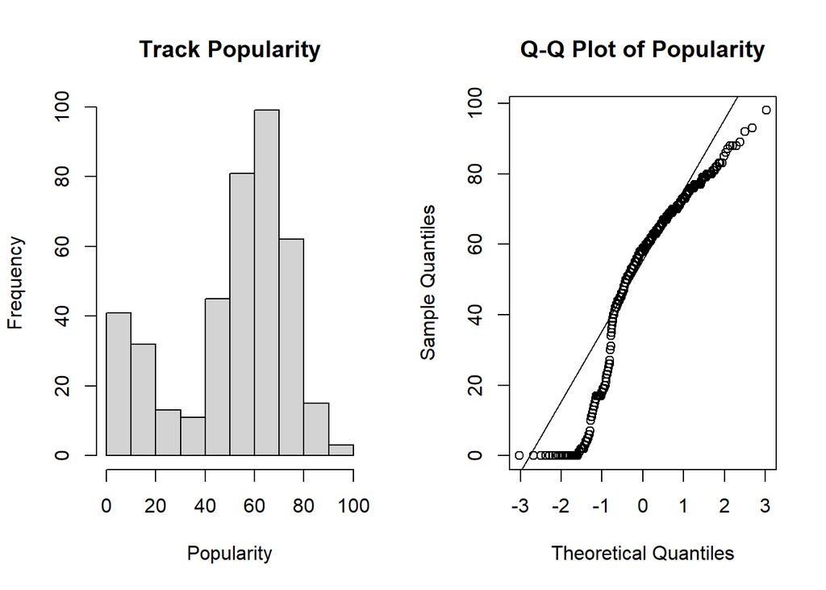

```r
pop_mean <- mean(music_data$popularity)

par(mfrow = c(1,2))
hist(music_data$popularity, main = "Track Popularity", xlab = "Popularity")
qqnorm(music_data$popularity, main = "Q-Q Plot of Popularity")
qqline(music_data$popularity)
```

Visual analysis of popularity plots suggest it is not normally-distributed. Tracks have a mean popularity of 51.4, unsurprisingly average in my opinion. It is peculiar that there are a large number of tracks with very low popularity, I wonder why that is.

### Energy & Valence

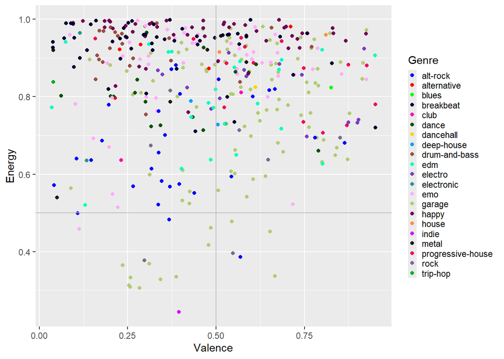

```r
ggplot(music_data, aes(x = valence, y = energy, colour = track_genre)) +
  geom_point() +
  scale_colour_manual(values = colours) +
  guides(colour = guide_legend(ncol = 1)) +
  theme(legend.key.height = unit(0.35, "cm"), legend.key.width = unit(0.3, "cm")) +
  geom_hline(yintercept = 0.5, colour = "grey") +
  geom_vline(xintercept = 0.5, colour = "grey") +
  labs(x = "Valence", y = "Energy", colour = "Genre")
```

The music I listen to appears to be very energetic, and spans the entire valence scale, meaning the music I listen to has wide range of emotions.

“Heavier” music (rock, metal, etc) tends to be “angrier”.

### Do I have Tinnitus?

Yes.

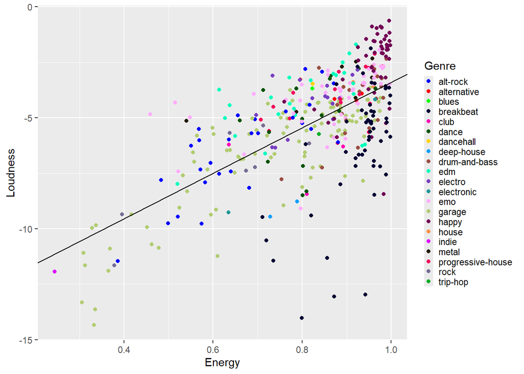

```r
loud_enrg_reg <- lm(formula = loudness ~ energy, data = music_data)
coeff<-coefficients(loud_enrg_reg)
intercept<-coeff[1]
slope<- coeff[2]

ggplot(music_data, aes(x = energy, y = loudness, colour = track_genre)) +
  geom_point() +
  scale_colour_manual(values = colours) +
  guides(colour = guide_legend(ncol = 1)) +
  theme(legend.key.height = unit(0.34, "cm"), legend.key.width = unit(0.3, "cm")) +
  labs(x = "Energy", y = "Loudness", colour = "Genre") +
  geom_abline(intercept = intercept, slope = slope)
```

```r
l_e_corr_test <- cor.test(x = music_data$energy, y = music_data$loudness, method = "pearson")
```

### Danceability

Since I listen to a lot of EDM (electronic *dance* music), just how danceable is it?

To check this, I put all the tracks into one of two categories on whether I consider their genre a part of EDM or not.

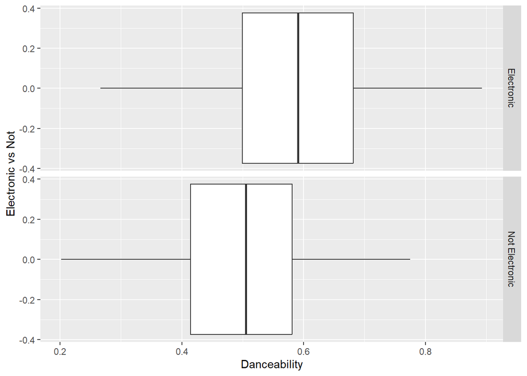

```r
edm_genres <- c("trip-hop", "progressive-house", "house", "happy", "electronic", "electro", "edm", "drum-and-bass", "deep-house", "dancehall", "dance", "club", "breakbeat")

music_data$is_electronic <- NA
for(i in 1:402){
  if((music_data[i, "track_genre"]) %in% edm_genres){
    music_data[i, "is_electronic"] <- "Electronic"
  } else{
    music_data[i, "is_electronic"] <- "Not Electronic"
  }
}

ggplot(music_data, aes(x = danceability)) +
  geom_boxplot() +
  facet_grid(is_electronic ~ .) +
  labs(x = "Danceability", y = "Electronic vs Not")
```

As the boxplots shows, there is in fact a difference in danceability between the two categories. Performing a t-test reaches the same conclusion, the mean danceability is significantly higher for electronic genres.

```r
test_data <- data.frame(
  Designation = factor(music_data$is_electronic),
  Danceability = music_data$danceability
)
t.test(test_data$Danceability ~ test_data$Designation)
```

```
    Welch Two Sample t-test

data:  test_data$Danceability by test_data$Designation
t = 7.5984, df = 398.8, p-value = 2.16e-13
alternative hypothesis: true difference in means between group Electronic and group Not Electronic is not equal to 0
95 percent confidence interval:
 0.06970073 0.11835712
sample estimates:
    mean in group Electronic mean in group Not Electronic
                   0.5892330                    0.4952041
```

## Conclusion

To wrap this up somehow, this has been an insight into my music tastes. My tastes are certainly varied but all still have a thread of commonality. A more in-depth analysis, using specific song lists rather than just artist discographies is bound to yield even more insights.